# Metagenomics

Prof. Harbert

Meeting 19

# Taxonomic Classification of DNA

The ability to generate massive datasets through massively parallel DNA sequencing technologies has made it possible to generate enough genetic information to identify organisms from trace amounts (even single molecules) of DNA evidence.

However, distilling these massive datasets down to useful information requires more advanced and efficient algorithms as we compare larger and larger amounts of data to even bigger reference databases.

# Meta *

There is some confusion in the scientific literature regarding the proper terms for these techniques. The consensus seems to be:

**Metabarcoding**: Classifying single gene/short regions of amplified DNA from many sources. (Related to DNA barcoding –> identifying specific samples based on a short region of DNA sequence)

**Metagenomics**: Classifying mixed whole genome data from many organisms. Example: assembling genomes for multiple bacterial strains in a mixed community.

**Metataxonomics**: Classifying DNA sequence data from mixed samples to identify what organisms are present.

However, many people use metagenomics to cover the last two (-genomics and -taxonomics). We will explore the techniques primarily for metataxonomics.

# Reference Databases

Tour: https://www.ncbi.nlm.nih.gov/ and ftp://ftp.ncbi.nlm.nih.gov/

## Setting up a Reference Database

These data come from the early genome sequencing of SARS-CoV-2 when scientists in Wuhan, China were working on identifying the causitive agent of an unknown respiratory syndrome causing pneumonia and death.

One approach to the problem might have been to classify the unknown data from the RNA metagenomic sample collected from a patient against a database of all known viral sequences.

*Setup a new working directory*

```r
dir.create('metagenomics')
setwd('metagenomics')
```

*Download a reference file*

```r
# from: ftp://ftp.ncbi.nlm.nih.gov/refseq/release/viral
dir.create('ref')
download.file('ftp://ftp.ncbi.nlm.nih.gov/refseq/release/viral/viral.1.1.genomic.fna.gz', 'ref/viral.1.1.genomic.fna.gz')
download.file('ftp://ftp.ncbi.nlm.nih.gov/refseq/release/viral/viral.2.1.genomic.fna.gz', 'ref/viral.2.1.genomic.fna.gz')
download.file('ftp://ftp.ncbi.nlm.nih.gov/refseq/release/viral/viral.3.1.genomic.fna.gz', 'ref/viral.3.1.genomic.fna.gz')

# unzip and put all of the viral reference files into one:
system("gunzip ref/*")
system("cat ref/*.fna > ref/viral_all.fasta")
```

*Downlaod raw sequence data*

This may take a few minutes…

```r
dir.create('data')
options(timeout=9999) # set a higher timeout for larger downloads
download.file('https://sra-pub-sars-cov2.s3.amazonaws.com/sra-src/SRR11092062/v300043428_L02_127_1.fq.gz', 'data/viral_metagenome.fq.gz', extra = 'curl')
system('gunzip data/viral_metagenome.fq.gz')
```

# BLAST for classification

As we have seen already, BLAST is a popular algorithm for searching for similar nucleotide sequences. Here we will implement a metagenomic search for a set of unknown raw sequence data.

```r
suppressMessages(library(rBLAST)) #quiet down Biostrings!
library(ggplot2)

list.files(recursive = T)
```

```
## [1] "data/viral_metagenome.fq"  "nameNode.sqlite"
## [3] "ref/viral_all.fasta"       "ref/viral_all.fasta.nhr"
## [5] "ref/viral_all.fasta.nin"   "ref/viral_all.fasta.nsq"
## [7] "ref/viral.1.1.genomic.fna" "ref/viral.2.1.genomic.fna"
## [9] "ref/viral.3.1.genomic.fna"
```

```r
# read in the query data as a DNAStringSet
fq <- readDNAStringSet('data/viral_metagenome.fq',format = 'fastq')
head(fq)
```

```
## DNAStringSet object of length 6:
##     width seq                                               names
## [1]   150 GCTGAAACCATGCCATGAACCTG...GTTGCTGTTGCTACCACTACAAC v300043428L2C001R...
## [2]   150 GCGGTGTGTACAAAGGGCAGGGA...CCGCGCCTGCCGGCGTAGGGTAG v300043428L2C001R...
## [3]   150 AGCTTCCCTGGCAAATGTGCAGC...ATGCTGCTGTTTGCACAGCTCCA v300043428L2C001R...
## [4]   150 GATTAAAGACTTACATGTTAGAC...GACAAAATTGACAAATGGGATCT v300043428L2C001R...
## [5]   150 CACCATTACCATTGTTCCTGGCC...TTCTTTCAAGTCGGAGGCCAAGC v300043428L2C001R...
## [6]   150 CGCCTGGGCCTGCAGTGGCAGTC...GTGGTTGGTCAGGATGTGAGAGT v300043428L2C001R...
```

```r
#make a new blast database to search
reference = 'ref/viral_all.fasta'
makeblastdb(reference, dbtype = "nucl")

# search the database
#prepare
bl <- blast(db=reference, type='blastn')

##### PARALLEL COMPUTING WITH BLAST #####
#run parallel blast searches
library(parallel)
parpredict = function(x){
return(predict(bl, x))
}
clus = makeCluster('16', type ='FORK');
splits = clusterSplit(clus, fq)
p_cl = parLapply(clus, splits, parpredict)
stopCluster(clus)
cl = dplyr::bind_rows(p_cl)
##### END PARALLEL COMPUTING #####
```

# Visualizing Results

## Lookup taxonomy

[About the taxonomizr R package here](https://cran.r-project.org/web/packages/taxonomizr/vignettes/usage.html) Build taxonomy database (may take a few minutes).

```r
#install.packages("taxonomizr")
library(taxonomizr)
```

*DO NOT RUN* Your instructor will share a copy of the prepared database.

```r
dir.create('taxonomy')
prepareDatabase('taxonomy/accessionTaxa.sql') # this takes a while
```

*Load the database*

```r
  # find and load the taxonomizr databases
  # or ammend to the copy your instructor provides in class
  tax_db = '../../../../bio331/db/taxonomy'
  tax_db_files = list.files(tax_db, full.names = TRUE)
  nodes = tax_db_files[grepl('nodes', tax_db_files)]
  names = tax_db_files[grepl('names', tax_db_files)]
  accession = tax_db_files[grepl('accessionTaxa', tax_db_files)]
  taxaNodes<-read.nodes.sql(nodes)
```

```
## nameNode.sqlite already contains table nodes. Delete file or set overwrite=TRUE to reload
```

```r
  taxaNames<-read.names.sql(names)
```

```
## nameNode.sqlite already contains table names. Delete file or set overwrite=TRUE to reload
```

*Search and append to BLAST results*

```r
accid = as.character(cl$SubjectID) # accession IDs of BLAST hits
#takes accession number and gets the taxonomic ID
ids<-accessionToTaxa(accid, accession)
#taxlist displays the taxonomic names from each ID #
taxlist=getTaxonomy(ids, taxaNodes, taxaNames)
cltax=cbind(cl,taxlist)
```

## Visualize

```r
library(ggplot2)
library(forcats)

summary(cltax)
```

```
##    QueryID           SubjectID           Perc.Ident     Alignment.Length
##  Length:950880      Length:950880      Min.   : 73.65   Min.   : 28.0
##  Class :character   Class :character   1st Qu.: 87.64   1st Qu.: 83.0
##  Mode  :character   Mode  :character   Median : 89.61   Median :122.0
##                                        Mean   : 90.20   Mean   :110.7
##                                        3rd Qu.: 92.13   3rd Qu.:142.0
##                                        Max.   :100.00   Max.   :173.0
##    Mismatches     Gap.Openings        Q.start           Q.end
##  Min.   : 0.00   Min.   : 0.0000   Min.   :  1.00   Min.   : 28.0
##  1st Qu.: 6.00   1st Qu.: 0.0000   1st Qu.:  1.00   1st Qu.:125.0
##  Median :10.00   Median : 1.0000   Median :  6.00   Median :147.0
##  Mean   :10.06   Mean   : 0.9761   Mean   : 22.99   Mean   :131.6
##  3rd Qu.:14.00   3rd Qu.: 1.0000   3rd Qu.: 37.00   3rd Qu.:150.0
##  Max.   :39.00   Max.   :15.0000   Max.   :123.00   Max.   :150.0
##     S.start            S.end               E                  Bits
##  Min.   :      1   Min.   :      1   Min.   :0.000e+00   Min.   : 52.8
##  1st Qu.:   8467   1st Qu.:   8472   1st Qu.:0.000e+00   1st Qu.:102.0
##  Median :   8553   Median :   8540   Median :0.000e+00   Median :143.0
##  Mean   :  10792   Mean   :  10795   Mean   :5.774e-08   Mean   :139.5
##  3rd Qu.:   8616   3rd Qu.:   8611   3rd Qu.:0.000e+00   3rd Qu.:171.0
##  Max.   :1876893   Max.   :1876893   Max.   :6.410e-06   Max.   :278.0
##  superkingdom          phylum             class              order
##  Length:950880      Length:950880      Length:950880      Length:950880
##  Class :character   Class :character   Class :character   Class :character
##  Mode  :character   Mode  :character   Mode  :character   Mode  :character
##
##
##
##     family             genus             species
##  Length:950880      Length:950880      Length:950880
##  Class :character   Class :character   Class :character
##  Mode  :character   Mode  :character   Mode  :character
##
##
##
```

```r
cltax95 <- cltax[which(cltax$Perc.Ident>95 & cltax$Alignment.Length>140),]
unique(cltax95$family)
```

```
## [1] "Coronaviridae" "Siphoviridae"  "Retroviridae"  "Poxviridae"
## [5] "Myoviridae"    "Herpesviridae" "Flaviviridae"
```

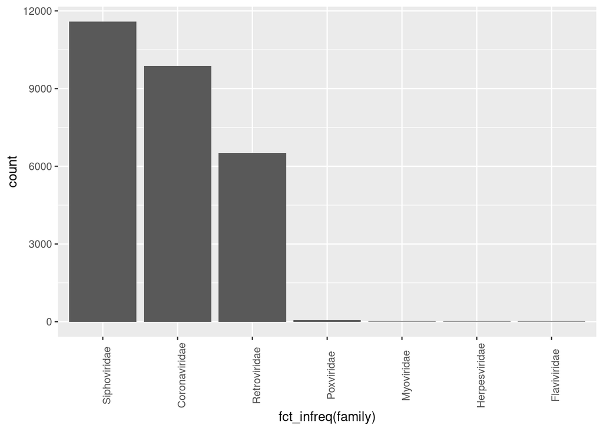

```r
ggplot(cltax95) +
  geom_bar(aes(x=fct_infreq(family))) +
  theme(axis.text.x = element_text(angle = 90))
```

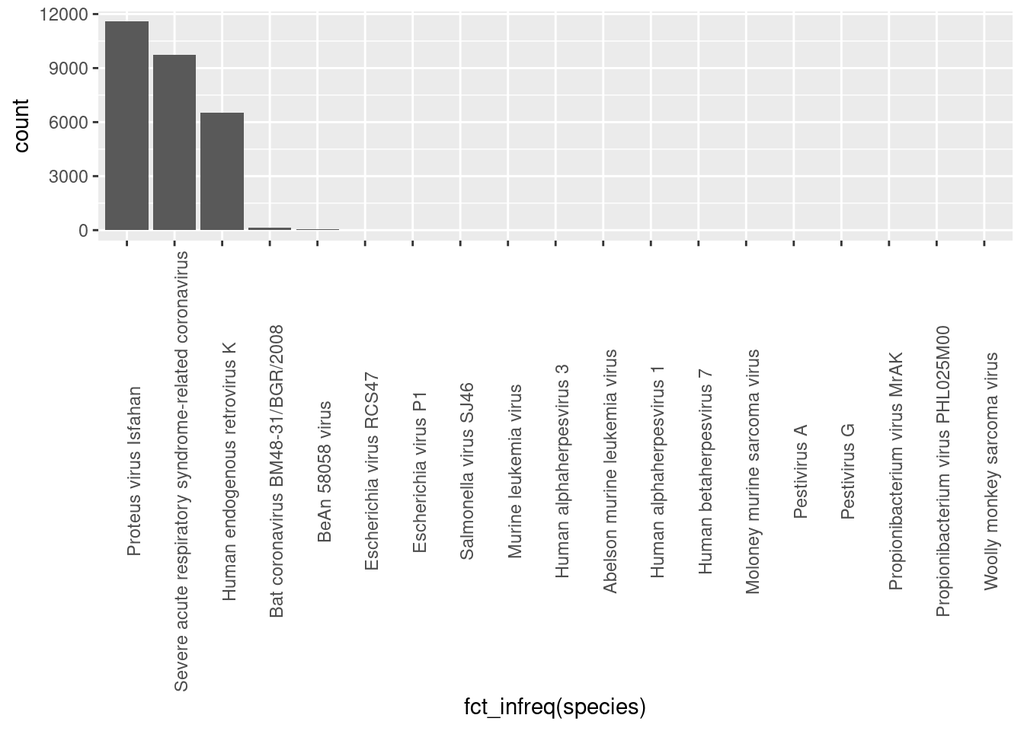

```r
ggplot(cltax95) +
  geom_bar(aes(x=fct_infreq(species))) +
  theme(axis.text.x = element_text(angle = 90))
```

What in the world is Protesu virus Isfahan? [See more about this bacteriophage here](https://pubmed.ncbi.nlm.nih.gov/30149052/)

Based on this analysis what is our most likely viral agent causing pneumonia in this patient?

# Reading: The Subway Microbiome

For discussion this week please read: http://dx.doi.org/10.1016/j.cels.2015.01.001

THEN, find another microbiome study and link it to the discussion with a short explanation of what it presents.

We will discuss the subway paper and other papers you find in class next time.